# QCSimulator.Rmd

Tinniam V Ganesh

June 22, 2016

```r
library(QCSimulator)
library(ggplot2)
```

# Initialize the environment and set global variables

```r
rm(list=ls())
#Call the init function to initialize the environment and create global variables
init()

# Display global variables in environment
ls()
```

```
##  [1] "I16"     "I2"      "I4"      "I8"      "q0_"     "q00_"    "q000_"
##  [8] "q0000_"  "q00000_" "q00001_" "q0001_"  "q00010_" "q00011_" "q001_"
## [15] "q0010_"  "q00100_" "q00101_" "q0011_"  "q00110_" "q00111_" "q01_"
## [22] "q010_"   "q0100_"  "q01000_" "q01001_" "q0101_"  "q01010_" "q01011_"
## [29] "q011_"   "q0110_"  "q01100_" "q01101_" "q0111_"  "q01111_" "q1_"
## [36] "q10_"    "q100_"   "q1000_"  "q10000_" "q10001_" "q1001_"  "q10010_"
## [43] "q10011_" "q101_"   "q1010_"  "q10100_" "q10101_" "q1011_"  "q10110_"
## [50] "q10111_" "q11_"    "q110_"   "q1100_"  "q11000_" "q11001_" "q1101_"
## [57] "q11010_" "q11011_" "q111_"   "q1110_"  "q11100_" "q11101_" "q1111_"
## [64] "q11110_" "q11111_"
```

```r
# 2 x 2 Identity matrix
I2
```

```
##      [,1] [,2]
## [1,]    1    0
## [2,]    0    1
```

```r
# 8 x 8 Identity matrix
I8
```

```
##      [,1] [,2] [,3] [,4] [,5] [,6] [,7] [,8]
## [1,]    1    0    0    0    0    0    0    0
## [2,]    0    1    0    0    0    0    0    0
## [3,]    0    0    1    0    0    0    0    0
## [4,]    0    0    0    1    0    0    0    0
## [5,]    0    0    0    0    1    0    0    0
## [6,]    0    0    0    0    0    1    0    0
## [7,]    0    0    0    0    0    0    1    0
## [8,]    0    0    0    0    0    0    0    1
```

```r
# Qubit |00>
q00_
```

```
##      [,1]
## [1,]    1
## [2,]    0
## [3,]    0
## [4,]    0
```

```r
# Qubit |010>
q010_
```

```
##      [,1]
## [1,]    0
## [2,]    0
## [3,]    1
## [4,]    0
## [5,]    0
## [6,]    0
## [7,]    0
## [8,]    0
```

```r
# Qubit |0100>
q0100_
```

```
##       [,1]
##  [1,]    0
##  [2,]    0
##  [3,]    0
##  [4,]    0
##  [5,]    1
##  [6,]    0
##  [7,]    0
##  [8,]    0
##  [9,]    0
## [10,]    0
## [11,]    0
## [12,]    0
## [13,]    0
## [14,]    0
## [15,]    0
## [16,]    0
```

```r
# Qubit 10010
q10010_
```

```
##       [,1]
##  [1,]    0
##  [2,]    0
##  [3,]    0
##  [4,]    0
##  [5,]    0
##  [6,]    0
##  [7,]    0
##  [8,]    0
##  [9,]    0
## [10,]    0
## [11,]    0
## [12,]    0
## [13,]    0
## [14,]    0
```

[output cut: 18 more lines]

### To display the unitary matrix of gates

To check the unitary matrix of gates we need to pass the appropriate identity matrix. Hence below the qubit gates require a 2 x 2 unitary matrix and the 2 & 3 qubit CNOT gates require a 4 x 4 and 8 x 8 identity matrix respectivelt

```r
PauliX(I2)
```

```
##      [,1] [,2]
## [1,]    0    1
## [2,]    1    0
```

```r
Hadamard(I2)
```

```
##           [,1]       [,2]
## [1,] 0.7071068  0.7071068
## [2,] 0.7071068 -0.7071068
```

```r
S1Gate(I2)
```

```
##      [,1] [,2]
## [1,] 1+0i 0+0i
## [2,] 0+0i 0-1i
```

```r
CNOT2_10(I4)
```

```
##      [,1] [,2] [,3] [,4]
## [1,]    1    0    0    0
## [2,]    0    0    0    1
## [3,]    0    0    1    0
## [4,]    0    1    0    0
```

```r
CNOT3_20(I8)
```

```
##      [,1] [,2] [,3] [,4] [,5] [,6] [,7] [,8]
## [1,]    1    0    0    0    0    0    0    0
## [2,]    0    0    0    0    0    1    0    0
## [3,]    0    0    1    0    0    0    0    0
## [4,]    0    0    0    0    0    0    0    1
## [5,]    0    0    0    0    1    0    0    0
## [6,]    0    1    0    0    0    0    0    0
## [7,]    0    0    0    0    0    0    1    0
## [8,]    0    0    0    1    0    0    0    0
```

### Applying gates

**Note** To apply a quantum gate the gate can be called by passing the identity matrix to it. For e.g applying take a look at the following.

Q0 – Hadamard - PauliZ Q1 – TGate- Hadamard

```r
Q0 = PauliZ(Hadamard(I2))
Q0
```

```
##            [,1]      [,2]
## [1,]  0.7071068 0.7071068
## [2,] -0.7071068 0.7071068
```

```r
Q1 = Hadamard(TGate(I2))
Q1
```

```
##              [,1]      [,2]
## [1,] 0.7071068+0i  0.5+0.5i
## [2,] 0.7071068+0i -0.5-0.5i
```

### Compute the inner product of vectors

For example of phi = 1/2|0> + sqrt(3)/2|1> and si= 1/sqrt(2)(10> + |1>) then the inner product is the dot product of the vectors

```r
phi = matrix(c(1/2,sqrt(3)/2),nrow=2,ncol=1)
si = matrix(c(1/sqrt(2),1/sqrt(2)),nrow=2,ncol=1)
angle= innerProduct(phi,si)
cat("Angle between vectors is:",angle)
```

```
## Angle between vectors is: 15
```

### Compute the dagger function for a gate

The gate dagger computes and displays the transpose of the complex conjugate of the matrix

```r
TGate(I2)
```

```
##      [,1]                 [,2]
## [1,] 1+0i 0.0000000+0.0000000i
## [2,] 0+0i 0.7071068+0.7071068i
```

```r
GateDagger(TGate(I2))
```

```
##      [,1]                 [,2]
## [1,] 1+0i 0.0000000+0.0000000i
## [2,] 0+0i 0.7071068-0.7071068i
```

### To display the unitary matrix of gates

To check the unitary matrix of gates we need to pass the appropriate identity matrix. Hence below the qubit gates require a 2 x 2 unitary matrix and the 2 & 3 qubit CNOT gates require a 4 x 4 and 8 x 8 identity matrix respectivelt

```r
PauliX(I2)
```

```
##      [,1] [,2]
## [1,]    0    1
## [2,]    1    0
```

```r
Hadamard(I2)
```

```
##           [,1]       [,2]
## [1,] 0.7071068  0.7071068
## [2,] 0.7071068 -0.7071068
```

```r
S1Gate(I2)
```

```
##      [,1] [,2]
## [1,] 1+0i 0+0i
## [2,] 0+0i 0-1i
```

```r
CNOT2_10(I4)
```

```
##      [,1] [,2] [,3] [,4]
## [1,]    1    0    0    0
## [2,]    0    0    0    1
## [3,]    0    0    1    0
## [4,]    0    1    0    0
```

```r
CNOT3_20(I8)
```

```
##      [,1] [,2] [,3] [,4] [,5] [,6] [,7] [,8]
## [1,]    1    0    0    0    0    0    0    0
## [2,]    0    0    0    0    0    1    0    0
## [3,]    0    0    1    0    0    0    0    0
## [4,]    0    0    0    0    0    0    0    1
## [5,]    0    0    0    0    1    0    0    0
## [6,]    0    1    0    0    0    0    0    0
## [7,]    0    0    0    0    0    0    1    0
## [8,]    0    0    0    1    0    0    0    0
```

# Invoking gates in series

The Quantum gates can be chained by passing each preceding Quantum gate as the argument.

```r
# Call in reverse order
# Superposition states
# |+> state
Hadamard(q0_)
```

```
##           [,1]
## [1,] 0.7071068
## [2,] 0.7071068
```

```r
# |->
PauliZ(Hadamard(q0_))
```

```
##            [,1]
## [1,]  0.7071068
## [2,] -0.7071068
```

```r
# (+i) Y
 SGate(Hadamard(q0_))
```

```
##                      [,1]
## [1,] 0.7071068+0.0000000i
## [2,] 0.0000000+0.7071068i
```

```r
# (-i)Y
 S1Gate(Hadamard(q0_))
```

```
##                      [,1]
## [1,] 0.7071068+0.0000000i
## [2,] 0.0000000-0.7071068i
```

### More gates in series

#### TGate of depth 2

The Quantum circuit for a TGate of Depth 2 is

Q0 — Hadamard-TGate-Hadamard-TGate-SGate-Measurement

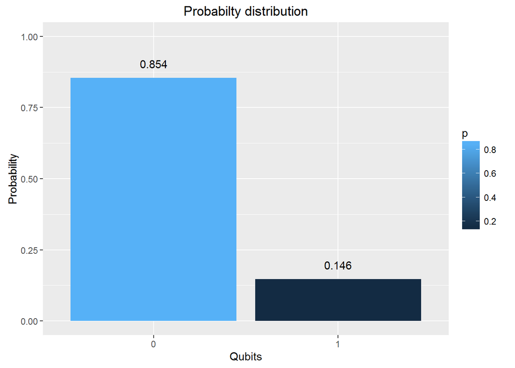

```r
# Invoking this in reverse order we get

a = SGate(TGate(Hadamard(TGate(Hadamard(q0_)))))
result=measurement(a)

plotMeasurement(result)
```

### Invoking gates in parallel

To obtain the results of gates in parallel we have to taje the Tensor Product

Q0 – Hadamard-Measurement Q1 – Identity- Measurement

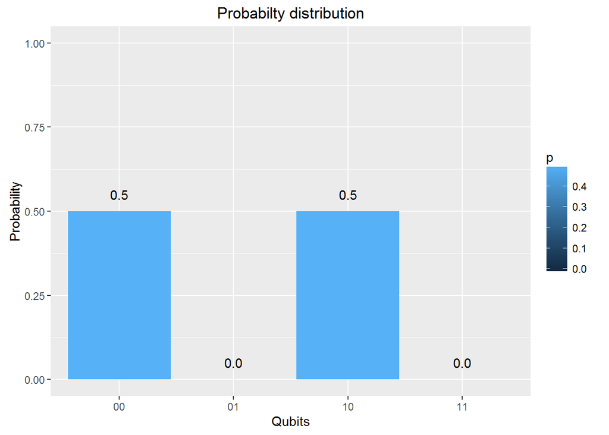

```r
#
a = TensorProd(Hadamard(I2),I2)
b = DotProduct(a,q00_)
plotMeasurement(measurement(b))
```

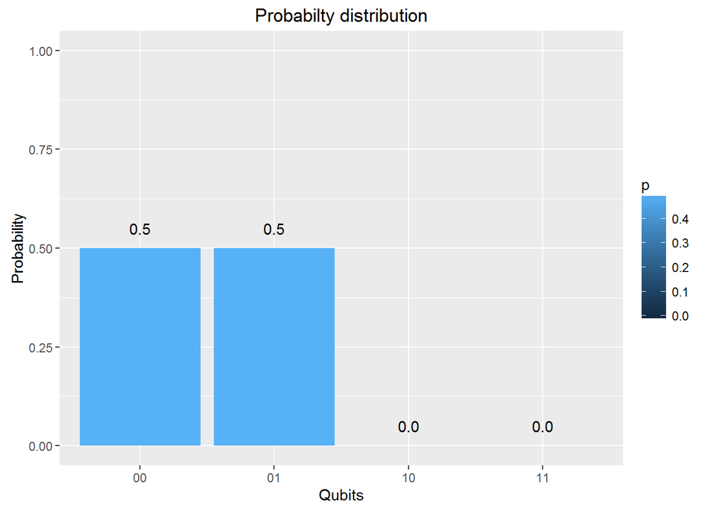

```r
a = TensorProd(PauliZ(I2),Hadamard(I2))
b = DotProduct(a,q00_)
plotMeasurement(measurement(b))
```

# Measurement

The measurement of a Quantum circuit can be obtained using the meaurement function. Consider the following Quantum circuit

Q0 - H-T-H-T-S-H-T-H-T-H-T-H-S-Measurement where H - Hadamard gate, T - T Gate and S- S Gate

```r
a = SGate(Hadamard(TGate(Hadamard(TGate(Hadamard(TGate(Hadamard(SGate(TGate(Hadamard(TGate(Hadamard(I2)))))))))))))
measurement(a)
```

[output not shown]

### Plot measurement

Using the same example as above Q0 - H-T-H-T-S-H-T-H-T-H-T-H-S-Measurement where H - Hadamard gate, T - T Gate and S- S Gate we can plot the measurement

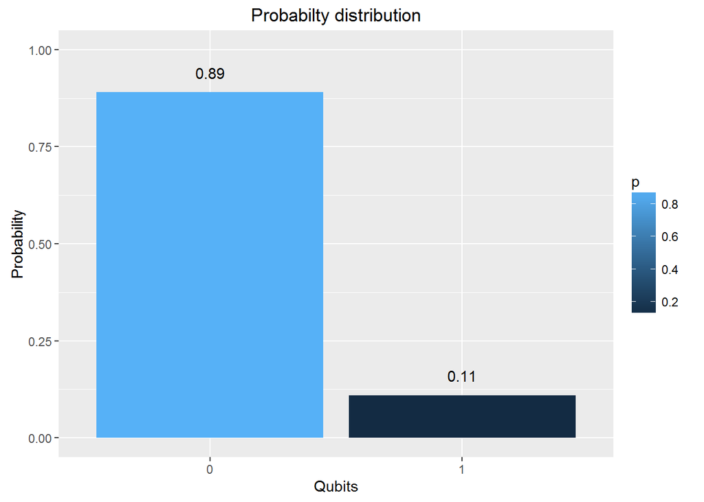

```r
a = SGate(Hadamard(TGate(Hadamard(TGate(Hadamard(TGate(Hadamard(SGate(TGate(Hadamard(TGate(Hadamard(I2)))))))))))))
result = measurement(a)
plotMeasurement(result)
```

### Evaluating a Quantum Circuit

The above procedure for evaluating a quantum gates in series and parallel can be used to evalute more complex quantum circuits were the quantum gates are in series and parallel.

Here is an evaluation of one such circuit, the Bell ZQ state using the QCSimulator

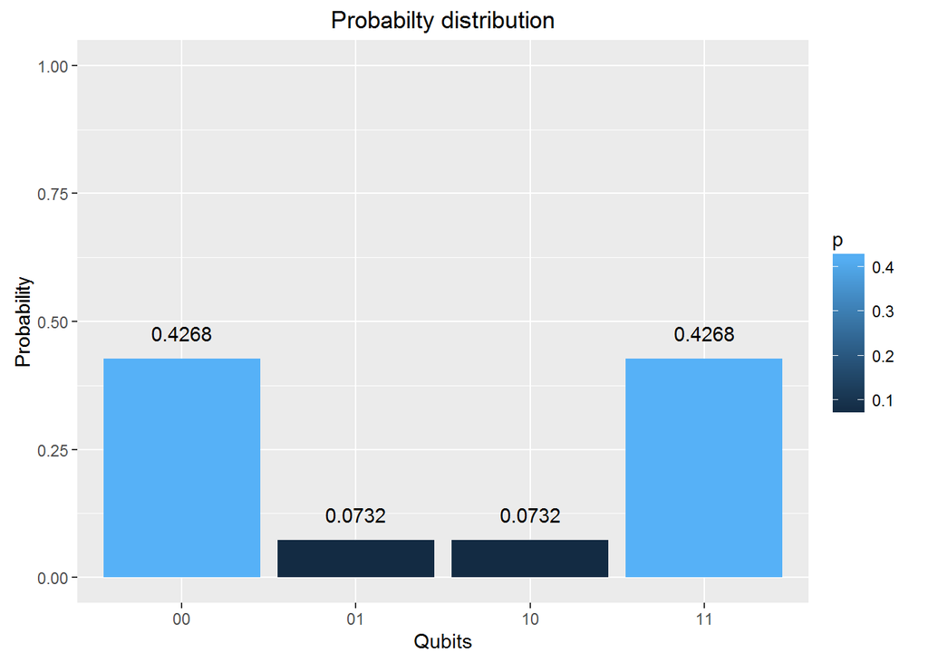

```r
# 1st composite
a = TensorProd(Hadamard(I2),I2)
# Output of CNOT
b = CNOT2_01(a)
# 2nd series
c=Hadamard(TGate(Hadamard(SGate(I2))))
#2nd composite
d= TensorProd(I2,c)
# Output of 2nd composite
e = DotProduct(b,d)
#Action of quantum circuit on |00>
f = DotProduct(e,q00_)
result= measurement(f)
plotMeasurement(result)
```

### Toffoli State

This circuit for this comes from IBM’s Quantum Experience. This circuit is available in the package. This is how the state was constructed

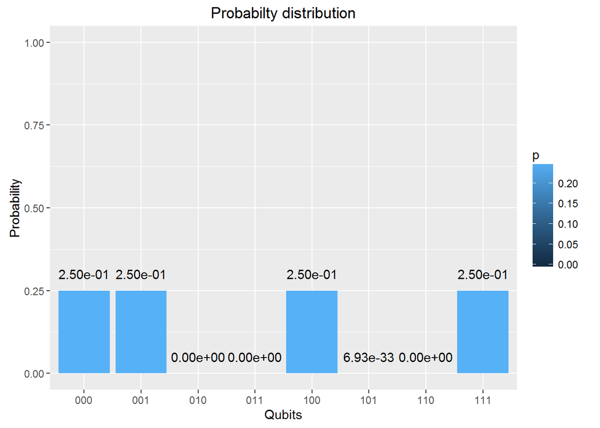

```r
  # Computation of the Toffoli State
    H=1/sqrt(2) * matrix(c(1,1,1,-1),nrow=2,ncol=2)
    I=matrix(c(1,0,0,1),nrow=2,ncol=2)

    # 1st composite
    # H x H x H
    a = TensorProd(TensorProd(H,H),H)
    # 1st CNOT
    a1= CNOT3_12(a)

    # 2nd composite
    # I x I x T1Gate
    b = TensorProd(TensorProd(I,I),T1Gate(I))
    b1 = DotProduct(b,a1)
    c = CNOT3_02(b1)

    # 3rd composite
    # I x I x TGate
    d = TensorProd(TensorProd(I,I),TGate(I))
    d1 = DotProduct(d,c)
    e = CNOT3_12(d1)

    # 4th composite
    # I x I x T1Gate
    f = TensorProd(TensorProd(I,I),T1Gate(I))
    f1 = DotProduct(f,e)
    g = CNOT3_02(f1)

    #5th composite
    # I x T x T
    h = TensorProd(TensorProd(I,TGate(I)),TGate(I))
    h1 = DotProduct(h,g)
    i = CNOT3_12(h1)

    #6th composite
    # I x H x H
    j = TensorProd(TensorProd(I,Hadamard(I)),Hadamard(I))
    j1 = DotProduct(j,i)
    k = CNOT3_12(j1)

    # 7th composite
    # I x H x H
    l = TensorProd(TensorProd(I,Hadamard(I)),Hadamard(I))
    l1 = DotProduct(l,k)
    m = CNOT3_12(l1)
    n = CNOT3_02(m)

    #8th composite
    # T x H x T1
    o = TensorProd(TensorProd(TGate(I),Hadamard(I)),T1Gate(I))
    o1 = DotProduct(o,n)
    p = CNOT3_02(o1)
    result = measurement(p)
    plotMeasurement(result)
```

### GHZ YYX measurement

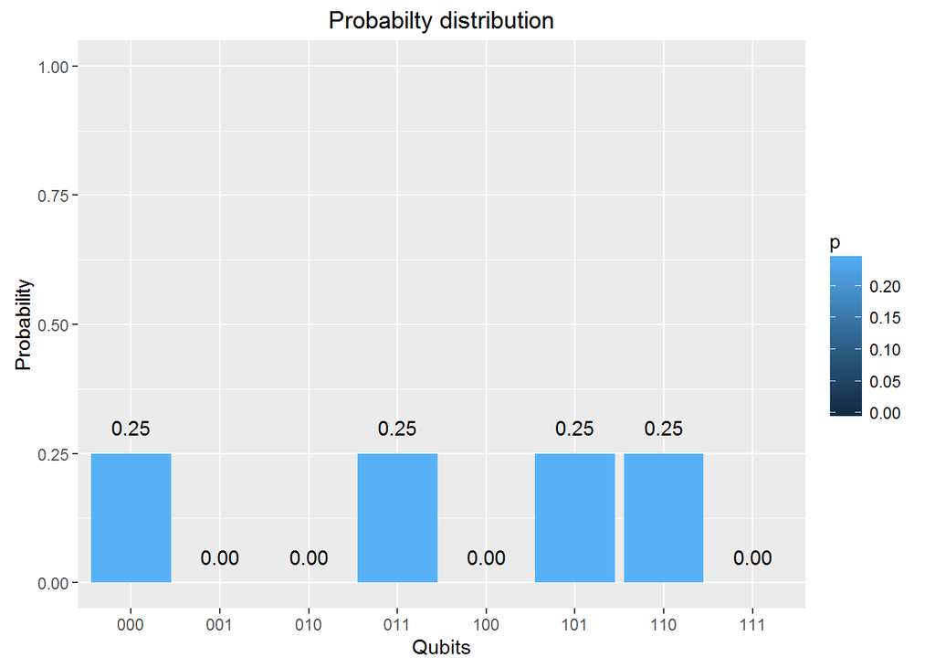

```r
a = TensorProd(TensorProd(Hadamard(I2),Hadamard(I2)),PauliX(I2))
b= CNOT3_12(a)
c= CNOT3_02(b)
d= TensorProd(TensorProd(Hadamard(I2),Hadamard(I2)),Hadamard(I2))
e= DotProduct(d,c)
f= TensorProd(TensorProd(S1Gate(I2),S1Gate(I2)),Hadamard(I2))
g= DotProduct(f,e)
i= TensorProd(TensorProd(Hadamard(I2),Hadamard(I2)),I2)
j = DotProduct(i,g)
result=measurement(j)
plotMeasurement(result)
```